# 561_notes

Shivam Verma

15/12/2019

#### Model with interaction (we multiply variables)

- Each category should have its own slope!!
- $Y_i=\beta_0 + \beta_1 X_{i1} + \beta_2 X_{i2} + \beta_3 X_{i3} + \beta_4 X_{i1} * X_{i3} + \beta_5 X_{i2} * X_{i3} + \varepsilon_i$

```r
summary(lm(Sepal.Width~Sepal.Length*Species, data = iris))
```

```
##
## Call:
## lm(formula = Sepal.Width ~ Sepal.Length * Species, data = iris)
##
## Residuals:
##      Min       1Q   Median       3Q      Max
## -0.72394 -0.16327 -0.00289  0.16457  0.60954
##
## Coefficients:
##                                Estimate Std. Error t value Pr(>|t|)
## (Intercept)                     -0.5694     0.5539  -1.028 0.305622
## Sepal.Length                     0.7985     0.1104   7.235 2.55e-11 ***
## Speciesversicolor                1.4416     0.7130   2.022 0.045056 *
## Speciesvirginica                 2.0157     0.6861   2.938 0.003848 **
## Sepal.Length:Speciesversicolor  -0.4788     0.1337  -3.582 0.000465 ***
## Sepal.Length:Speciesvirginica   -0.5666     0.1262  -4.490 1.45e-05 ***
## ---
## Signif. codes:  0 '***' 0.001 '**' 0.01 '*' 0.05 '.' 0.1 ' ' 1
##
## Residual standard error: 0.2723 on 144 degrees of freedom
## Multiple R-squared:  0.6227, Adjusted R-squared:  0.6096
## F-statistic: 47.53 on 5 and 144 DF,  p-value: < 2.2e-16
```

F statistic is also called (Coefficient of partial determination)  
- [see:](https://en.wikipedia.org/wiki/Coefficient_of_determination)  
- [See also](http://facweb.cs.depaul.edu/sjost/csc423/documents/f-test-reg.htm)  
- The formula: `((SS_res_reduced-SS_res_full)/k)/(SS_res_full/(n-p-1))`.  
* `k` is number of parameters which is different  
* `p` is number of parameters in the full model  
* `n` is number of rows in the dataset

```r
gpa_data <- read_csv("C:/MyDisk/MDS/DSCI_561/DSCI_561_lab3_sverma92/gpa_data.csv")
model_1 <- lm(univ_gpa~high_gpa, gpa_data)
model_2 <- lm(univ_gpa~high_gpa+math_sat, gpa_data)

####
# Comparing model1 with null intercept only model
SS_res_reduced <- sum((gpa_data$univ_gpa - mean(gpa_data$univ_gpa))^2)
SS_res_full <- sum((broom::augment(model_1)$.resid)^2)
k <- 1
n <- nrow(gpa_data)
p <- 1

F_stas <- ((SS_res_reduced - SS_res_full)/k)/(SS_res_full/(n-p-1))
anova(lm(univ_gpa~1, gpa_data), model_1)
```

```
## Analysis of Variance Table
##
## Model 1: univ_gpa ~ 1
## Model 2: univ_gpa ~ high_gpa
##   Res.Df     RSS Df Sum of Sq      F    Pr(>F)
## 1    104 20.7981
## 2    103  8.1587  1    12.639 159.57 < 2.2e-16 ***
## ---
## Signif. codes:  0 '***' 0.001 '**' 0.01 '*' 0.05 '.' 0.1 ' ' 1
```

```r
# Comparing model2 with null intercept only model
SS_res_full <- sum((broom::augment(model_2)$.resid)^2)
k <- 2
n <- nrow(gpa_data)
p <- 2

F_stas <- ((SS_res_reduced - SS_res_full)/k)/(SS_res_full/(n-p-1))
anova(lm(univ_gpa~1, gpa_data), model_2)
```

```
## Analysis of Variance Table
##
## Model 1: univ_gpa ~ 1
## Model 2: univ_gpa ~ high_gpa + math_sat
##   Res.Df     RSS Df Sum of Sq      F    Pr(>F)
## 1    104 20.7981
## 2    102  7.9511  2    12.847 82.403 < 2.2e-16 ***
## ---
## Signif. codes:  0 '***' 0.001 '**' 0.01 '*' 0.05 '.' 0.1 ' ' 1
```

```r
# Comparing model2 with model1
SS_res_reduced <- sum((broom::augment(model_1)$.resid)^2)
k <- 1
n <- nrow(gpa_data)
p <- 2

F_stas <- ((SS_res_reduced - SS_res_full)/k)/(SS_res_full/(n-p-1))
anova(model_1, model_2)
```

```
## Analysis of Variance Table
##
## Model 1: univ_gpa ~ high_gpa
## Model 2: univ_gpa ~ high_gpa + math_sat
##   Res.Df    RSS Df Sum of Sq      F Pr(>F)
## 1    103 8.1587
## 2    102 7.9511  1   0.20759 2.6631 0.1058
```

```r
####

print(paste("The t-statistic from tidy is:", round(tidy(model_2)$statistic[3], digits=3), "square of which is:", round(tidy(model_2)$statistic[3]^2, digits=3)))
```

```
## [1] "The t-statistic from tidy is: 1.632 square of which is: 2.663"
```

```r
print(paste("The F-statistic from anova is:", round(tidy(anova(model_1, model_2))$statistic[2], digits=3)))
```

```
## [1] "The F-statistic from anova is: 2.663"
```

> In the special case of comparing the two exact same hypotheses in a least squares linear model, it can be shown that the F-statistic is equal to the T-statistic squared, and that the p-value of the F-test and T-test are equal (see [here](https://canovasjm.netlify.com/2018/10/29/when-does-the-f-test-reduce-to-t-test/) for more). For example, when you use glance() on the model_1 object, you are performing an F-test comparing the null model to the model_1 object

When you call `anova(model_1, model_2)` then hypothesis that is getting tested is as follows:
$$H_0: \beta_2=0$$
$$H_A: \beta_2\neq0$$
We observe equivalent t-test in the `tidy(model_2)` table where we test the coefficient of the second variable to be equal to 0.

### Association is not causation ([Read this awesome book](https://rafalab.github.io/dsbook/association-is-not-causation.html))

- This is perhaps the most important lesson one learns in a statistics class.

#### Spurious correlation ([Cool examples of spurious correlation](http://tylervigen.com/spurious-correlations))

- The cases presented in the spurious correlation site are all instances of what is generally called data dredging, data fishing, or data snooping. It’s basically a form of what in the US they call cherry picking. An example of data dredging would be if you look through many results produced by a random process and pick the one that shows a relationship that supports a theory you want to defend.
- A Monte Carlo simulation can be used to show how data dredging can result in finding high correlations among uncorrelated variables.

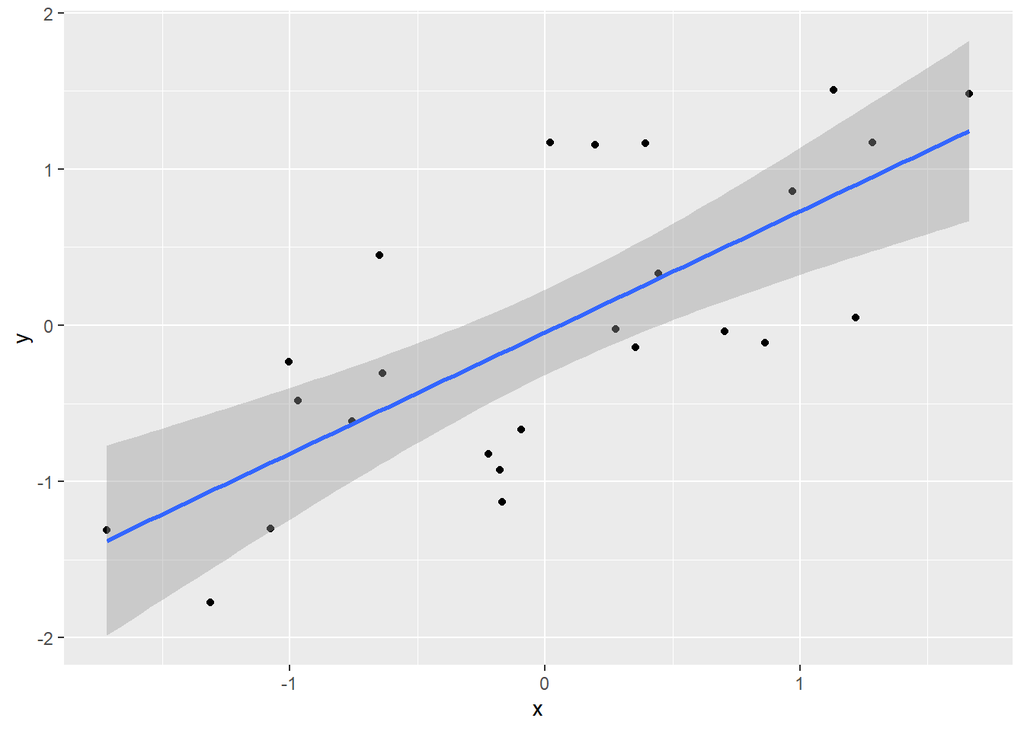

```r
N <- 25
g <- 100000
sim_data <- tibble(group = rep(1:g, each=N),
                   x = rnorm(N * g),
                   y = rnorm(N * g))

# Next, we compute the correlation between X and Y for each group and look at the max:
res <- sim_data %>%
  group_by(group) %>%
  summarize(r = cor(x, y)) %>%
  arrange(desc(r))

# plot the data from the group achieving max correlation
sim_data %>% filter(group == res$group[which.max(res$r)]) %>%
  ggplot(aes(x, y)) +
  geom_point() +
  geom_smooth(method = "lm")
```

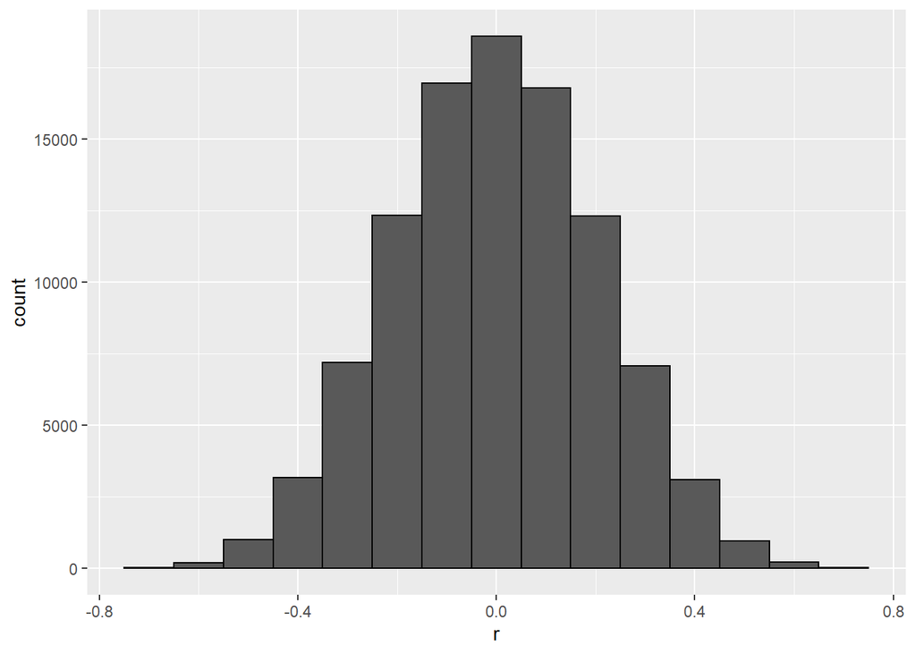

```r
# Distribution of all the correlations
res %>% ggplot(aes(x=r)) + geom_histogram(binwidth = 0.1, color = "black")
```

> If we performed regression on the highly correlated group and interpreted the p-value, we would incorrectly claim this was a statistically significant relation. This particular form of data dredging is referred to as p-hacking.

#### Outliers

> Suppose we take measurements from two independent outcomes, X and Y, and we standardize the measurements. However, imagine we make a mistake and forget to standardize entry 23. We can simulate such data using:

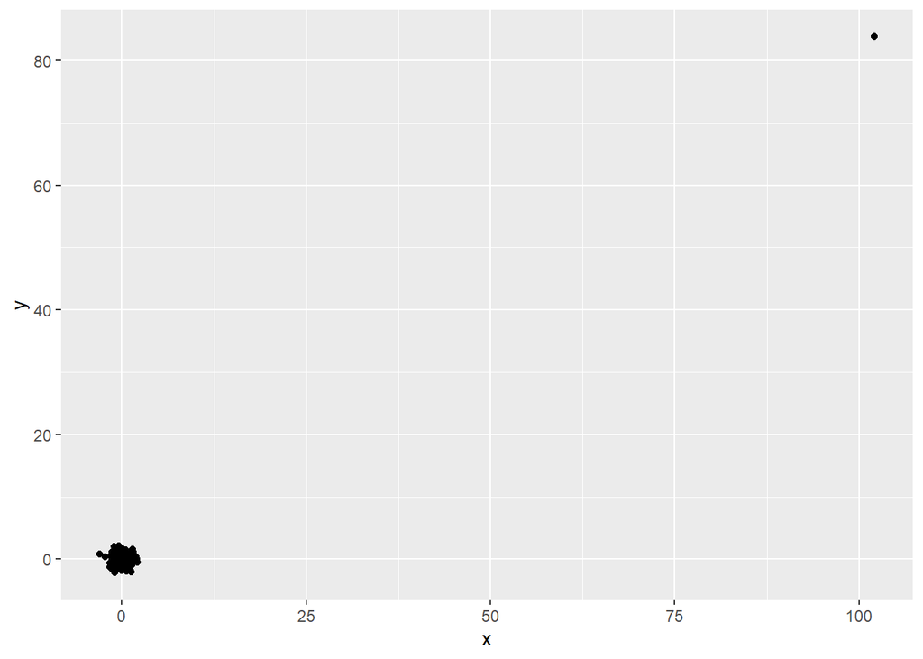

```r
set.seed(1985)
x <- rnorm(100,100,1)
y <- rnorm(100,84,1)
x[-23] <- scale(x[-23])
y[-23] <- scale(y[-23])

qplot(x, y)
```

```r
cor(x,y)
```

```
## [1] 0.9878382
```

```r
# But this is driven by the one outlier. If we remove this outlier, the correlation is greatly reduced to almost 0, which is what it should be:

cor(x[-23], y[-23])
```

```
## [1] -0.04419032
```

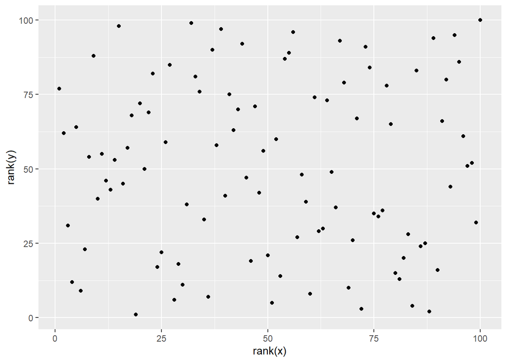

```r
# an alternative to the sample correlation for estimating the population correlation that is robust to outliers. It is called Spearman correlation. The idea is simple: compute the correlation on the ranks of the values. Here is a plot of the ranks plotted against each other:

qplot(rank(x), rank(y))
```

```r
# correlation
cor(rank(x), rank(y))
```

```
## [1] 0.002508251
```

```r
cor(x, y, method = "spearman")
```

```
## [1] 0.002508251
```

#### Reversing cause and effect

- Another way association is confused with causation is when the cause and effect are reversed. An example of this is claiming that tutoring makes students perform worse because they test lower than peers that are not tutored. In this case, the tutoring is not causing the low test scores, but the other way around.
- We can easily construct an example of cause and effect reversal using the father and son height data.

```r
library(HistData)
data("GaltonFamilies")
GaltonFamilies %>%
  filter(childNum == 1 & gender == "male") %>%
  select(father, childHeight) %>%
  rename(son = childHeight) %>%
  do(tidy(lm(father ~ son, data = .)))
```

```
## # A tibble: 2 x 5
##   term        estimate std.error statistic  p.value
##   <chr>          <dbl>     <dbl>     <dbl>    <dbl>
## 1 (Intercept)   34.0      4.57        7.44 4.31e-12
## 2 son            0.499    0.0648      7.70 9.47e-13
```

> The model fits the data very well. If we look at the mathematical formulation of the model above, it could easily be incorrectly interpreted so as to suggest that the son being tall caused the father to be tall. The model is technically correct. The estimates and p-values were obtained correctly as well. What is wrong here is the interpretation.

#### Confounding

- Confounders are perhaps the most common reason that leads to associations begin misinterpreted. If X and Y are correlated, we call Z a confounder if changes in Z causes changes in both X and Y.

> Admission data from six U.C. Berkeley majors, from 1973, showed that more men were being admitted than women: 44% men were admitted compared to 30% women.

```r
library(HistData)
data(admissions)
admissions %>% group_by(gender) %>%
  summarize(total_admitted = round(sum(admitted / 100 * applicants)),
            not_admitted = sum(applicants) - sum(total_admitted)) %>%
  select(-gender) %>%
  do(tidy(chisq.test(.))) %>% .$p.value
```

[output not shown]

```r
admissions %>% select(major, gender, admitted) %>%
  spread(gender, admitted) %>%
  mutate(women_minus_men = women - men)
```

[output not shown]

> The paradox is that analyzing the totals suggests a dependence between admission and gender, but when the data is grouped by major, this dependence seems to disappear. This actually can happen if an uncounted confounder is driving most of the variability.

> Plot the total percent admitted to a major versus the percent of women that made up the applicants:

```r
admissions %>%
  group_by(major) %>%
  summarize(major_selectivity = sum(admitted * applicants)/sum(applicants),
            percent_women_applicants = sum(applicants * (gender=="women")) /
                                             sum(applicants) * 100) %>%
  ggplot(aes(major_selectivity, percent_women_applicants, label = major)) +
  geom_text()
```

[output not shown]

> Controlling the confounder

```r
admissions %>%
  ggplot(aes(major, admitted, col = gender, size = applicants)) +
  geom_point()
admissions %>%  group_by(gender) %>% summarize(average = mean(admitted))
```

[output not shown]

> Confounding is addressed by adding the counfounding variable in the model

##### Example of Confounding Simpson’s Paradox

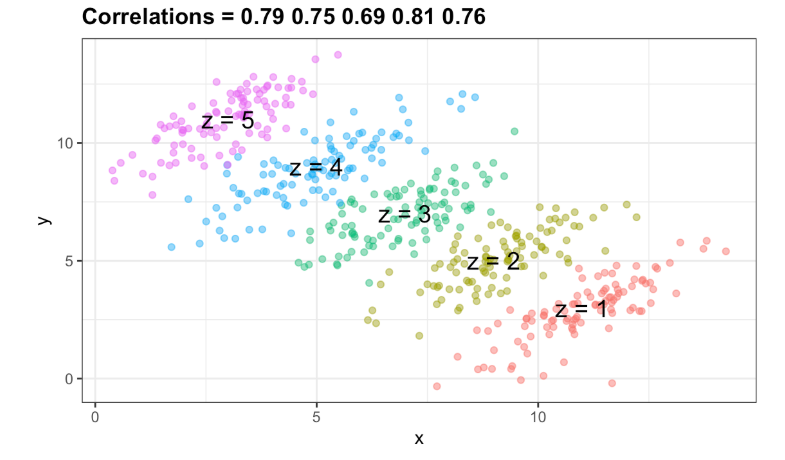

simpsons_paradox

> It is really Z that is negatively correlated with X. If we stratify by Z, the X and Y are actually positively correlated as seen in the plot above.

#### Sum of squares decomposition

- If parameters are estimated using LS and the LM has an intercept, TSS=ESS + RSS. Relate this to PCA if you remember that sum of squared deviation from the mean (origin) (TSS) = sum of squared distances between actual points & projected points (RSS) and the sum of squared deviation from mean of the projected points (ESS). But in this case the projection is the direction of yand not perpendicular.
- $\sum_{i=1}^n(y_i-\bar{y})^2 = \sum_{i=1}^n(\hat{y}_i-\bar{y})^2 + \sum_{i=1}^n(y_i - \hat{y}_i)^2$
- **Total Sum of Squares** $TSS=\sum_{i=1}^n(y_i-\bar{y})^2$. When properly scaled, it is the sample standard deviation of $Y$ which *estimates* the variance of $Y$
- **Explained Sum of Squares** $ESS=\sum_{i=1}^n(\hat{y}_i-\bar{y})^2$. $\hat{y}_i$ predicts $y_i$ using the LM, while $\bar{y}$ is the best predictor without a model. If our model is better than nothing, this should be large!!
- **Residual Sum of Squares** $RSS=\sum_{i=1}^n(y_i - \hat{y}_i)^2$. Our estimated parameters minimize this error!!
- $R^2=\frac{ESS}{TSS}$ is always positive
- $R^2=1-\frac{RSS}{TSS}$ is not always positive, RSS can be larger the TSS when the model does not have intercept or not LS estimates
- $(cor(y,\hat{y}))^2=R^2$, For a SLR model estimated by LS this is true, but it’s *not* true in general
- Although the $R^2$ compares the RSS of the *full model* vs those of the *null model*, it does not really tell us how good our model *predicts*
- The mean square error of prediction (PMSE) measures the distance between the predicted and the observed response
  - Can estimate both in-sample & out-sample
  - PMSE should be used to compare predicted with actual and not correlation as it can be confounded.
- Both the $R^2$ and the *F*-test are based on *in-sample* predictions and does not give a measure of accuracy in new test samples

We compute Bootstrapping or Permutation to HT for the LS estimates: they can be used if we believe the sample size is too small to trust asymptotic results. These tests can be used for other estimators as well.

#### Permutation test for regression

- We need to generate samples from the null hypothesis!! $H_0: \beta_g=0$
- Steps:
  1. Shuffle the rows of $X$ and combine them with the observed $y$
  2. Compute the estimate in the permuted sample
  3. Repeat 1-2 many times ($B$)
  4. Compute the $\text{p-value}=2 \times \frac{\#[\hat{\beta}^*> \hat{\beta}]}{B}$

#### Bootstrapping tests for regression

- There are 2 types of resampling: ($x$-random) & ($x$-fix). Only ($x$-random) is discussed
- In classical tests the statistic is: $T=\frac{\hat{\beta}-\beta_{H_0}}{\text{SE}[\hat{\beta}]}=\frac{\hat{\beta}-0}{\text{SE}[\hat{\beta}]}$
- The bootstrap statistic: $T^*=\frac{\beta^*-\hat{\beta}}{\text{SE}[\beta^*]}$, get $B$ of these!
- pval: $\frac{1+\#[|T^*| > |T|]}{B+1}$ to test $H_0:\beta_1=0$ vs $H_A: \beta_1 \neq 0$
- pval: $\frac{1+\#[T^* > T]}{B+1}$ to test $H_0:\beta_1=0$ vs $H_A: \beta_1 > 0$

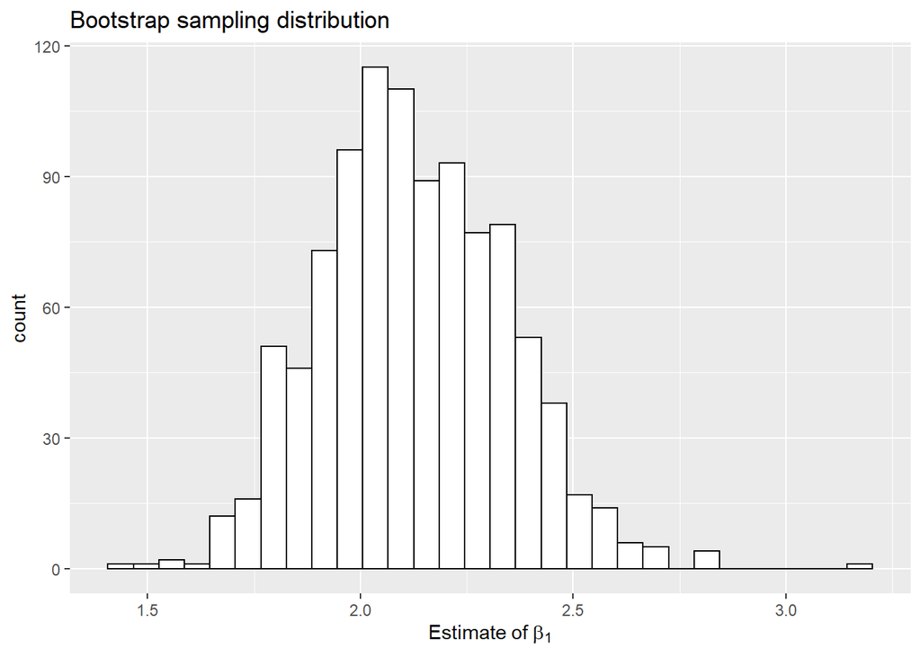

```r
# generate sample
n <- 200 # small n will result in skewed sampling distribution, high value will give more normal distribution (by CLT), but note that residuals are always non-normal, regardless of n
x <-  seq(1, n)
y <- x + rlnorm(n)*x
df <- tibble(x = x, y = y)
model <- lm(y ~ x, data = df)
df <- df %>%
  mutate(resid = predict(model) - y)
# generate bootstrap sampling distribution for beta_1
N <- 1000
boot_fits <- df %>%
    rsample::bootstraps(times = N) %>%
    mutate(
        lm   = map(splits, ~ lm(y ~ x, data = analysis(.x))),
        tidy = map(lm, broom::tidy)
    ) %>%
    select(-splits, -lm) %>%
    unnest(tidy) %>%
    filter(term == "x") %>%
    select(-term)

# plot bootstrap sampling distribution for beta_1
ggplot(boot_fits, aes(estimate)) +
    geom_histogram(bins = 30, color="black", fill="white") +
  ggtitle('Bootstrap sampling distribution') +
  labs(x = expression(Estimate~of~beta[1]))
```

```r
b_obs <- tidy(model)  %>% filter(term == "x") %>% select(estimate, statistic,p.value)

t_star <- data.frame(t_star=(boot_fits$estimate - b_obs$estimate)/boot_fits$std.error)

#pval using t-distribution
pval_t<-b_obs$p.value
print(paste("pval using t-distribution", pval_t))
```

```
## [1] "pval using t-distribution 1.94285241567769e-21"
```

```r
#pval using bootstrapping and pivot method
pval_boot <- (1+sum(abs(t_star) > abs(b_obs$statistic)))/(N+1)
print(paste("pval using bootstrapping and pivot method", pval_boot))
```

```
## [1] "pval using bootstrapping and pivot method 0.000999000999000999"
```

- The conditional expectation is the best predictor of 𝑌 given a vector of variables 𝑋
- A LM can be used as a predictor but it may not be the best
- If the data is jointly normal, the best predictor is linear!!
- The least squares regression is the best among other linear predictors
- Let’s only assume that the errors are $iid$ (independent and identically distributed) and independent of $X_j$
  - with $E[\varepsilon_i]=0$ and $Var(\varepsilon_i)=\sigma$
- Note that this assumption implies that $E[Y|\mathbf{X}]=\beta_0 + \beta_1 X_{i1} + \ldots + \beta_p X_{ip}$
  - this is just an assumption!! it’s true under normality but we are not assuming that (yet)
- Note that we are *not assuming* that $\varepsilon_i \sim \mathcal{N}(0,\sigma)$

### LS estimator

- Find $\beta_0, \beta_1, \ldots, \beta_p$ that minimizes the sum of squared errors: $\sum_i^n(Y_i - \beta_0 - \beta_1 X_{i1} - \ldots - \beta_p X_{ip})^2$
- The minimizer is the LS estimator : $\hat{\beta}_0, \hat{\beta}_1, \ldots, \hat{\beta}_p$

#### Properties of the LS estimator:

- Unbiased estimator meaning, $E[\hat{\mathbf{\beta}}]=\mathbf{\beta}$
- Best (lowest variance) Linear Unbiased Estimator
- $Var(\hat{\mathbf{\beta}})=\sigma^2(\mathbf{X}^T\mathbf{X})^{-1}, \; \hat{\sigma}=\sqrt{\frac{\sum_{i=1}^n\hat{e}_i^2}{n-p-1}}$ ($p$ slopes + 1 intercept)
  - `sig_hat <- augment(lm_s, dat_s) %>% select(.resid) %>% summarize(sig_hat= sqrt(sum(.resid^2)/(length(.resid)-2)))`
- This is the estimate given by `lm`!!
- The mean squared error for the estimator, not the prediction:
  - $\text{MSE}(\hat{\beta})=E[(\hat{\beta}-\beta)^2]= Var(\hat{\beta})+\text{Bias}(\hat{\beta})^2= Var(\hat{\beta})+(E(\hat{\beta})-\beta)^2$

#### Matrix Notation of the lienar model:

#### We want to minimize squared error:

- $S(\beta_0,\beta_1,\beta_2)=\mathbf{\varepsilon}^T\mathbf{\varepsilon}=(\mathbf{Y}- \mathbf{X} \mathbf{\beta})^T (\mathbf{Y} - \mathbf{X} \mathbf{\beta})$
- $\frac{\partial{S}}{\partial{\mathbf{\beta}}}=\mathbf{0}= -2\mathbf{X}^T(\mathbf{Y}-\mathbf{X}\mathbf{\beta}) \iff \mathbf{X}^T\mathbf{X}\hat{\mathbf{\beta}}=\mathbf{X}^T\mathbf{Y}$
- $\hat{\mathbf{\beta}}=(\mathbf{X}^T\mathbf{X})^{-1}\mathbf{X}^T\mathbf{Y}$
- Note that I *never* assume a distribution for $\varepsilon$. the errors does not have to be Normal!!
- Given $\mathbf{X}$, $\hat{\mathbf{\beta}}$ is a linear function of $\mathbf{Y}$, and $\mathbf{Y}$ has the same distribution as $\varepsilon_i$
- If $\varepsilon_i \sim \mathcal{N}(0,\sigma^2) \implies \hat{\mathbf{\beta}}$ is also Normal!! and we can construct an exact tests for the model coefficients
- $\hat{\beta}_1 \sim \mathcal{N}\left(\beta_1,\frac{\sigma^2}{(n-1)s_x^2}\right) \implies \quad z=\frac{\hat{\beta}_1-\beta_1}{SE(\hat{\beta}_1)}=\frac{\hat{\beta}_1-\beta_1}{\frac{\sigma}{\sqrt{(n-p-1)s^2_x}}} \sim \mathcal{N}(0,1)$
- Since $\sigma$ is usually *unknown*: $t=\frac{\hat{\beta}_1-\beta_1}{SE(\hat{\beta}_1)}=\frac{\hat{\beta}_1-\beta_1}{\frac{\hat{\sigma}}{\sqrt{(n-1)s^2_x}}} \sim \mathcal{t}_{n-p-1}$

#### What if $\varepsilon_i$ are *not* Normal??

- According to Central Limit Theorem, It can be proved that under certain conditions, the *asymptotic* sampling distribution of the LS estimators is *normal*, even when the errors are not!!. However, this result requires a large sample size (and “large” depends on characteristics of the sample).
- `lm` uses this result and constructs a *t*-statistic under the null hypothesis $H_0: \beta_j=0$ with $t=\frac{\hat{\beta}_j-0}{SE(\hat{\beta}_j)}\sim \mathcal{t}_{n-p-1}$

#### Confidence Intervals for Prediction (CIP)

- Example: “Are you predicting the average value of a house with the given dimensions?”
- The fitted value, $\hat{Y}$ (random variable) predicts the true value of conditional expectation of Y given X
- There is only 1 sources of variation for this prediction: the uncertainty of the estimated coefficients
- $\hat{Y}(x^*) \pm t_{n-2,0.975} \times SE_{\hat{\mu}_{Y|x^*}}; \; SE_{\hat{\mu}_{Y|x^*}}=\hat{\sigma} \sqrt{\frac{1}{n}+\frac{(x^*-\bar{x})^2}{(n-1)s_x^2}}$
- The *t*-distribution here is derived from the conditional distribution of $\varepsilon$ given $\mathbf{X}$. Thus, there is no CLT that we can rely on!! This result is assuming normality of the error terms!!

#### Prediction Intervals (PI)

- Example: “Are you predicting the value of this given house that has these dimensions?”
- The fitted value, $\hat{Y}$ predicts the *actual black point*.
- There are 2 sources of variation: the uncertainty of the estimated coefficients *and* that of the error that generates the data.
- PI are wider than CI for prediction.
- $\hat{Y}(x^*) \pm t_{n-2,0.975} \times SE(\hat{Y}(x^*))$; $SE(\hat{Y}(x^*))=\hat{\sigma} \sqrt{1+\frac{1}{n}+\frac{(x^*-\bar{x})^2}{(n-1)s_x^2}}$

#### Mulitcollinearity

- The least squares estimates satisfy: $\mathbf{X}^T\mathbf{X}\hat{\mathbf{\beta}}=\mathbf{X}^T\mathbf{Y}$. If $\mathbf{X}^T\mathbf{X}$ is non-singular (analogous to $\neq 0$), then $\hat{\mathbf{\beta}}=(\mathbf{X}^T\mathbf{X})^{-1}\mathbf{X}^T\mathbf{Y}$
- However, $\mathbf{X}^T\mathbf{X}$ becomes nearly singular or singular when explanatory variables are collinear or multicollinear, aka *multicollinearity problem*.
  - the solution $(\mathbf{X}^T\mathbf{X})^{-1}\mathbf{X}^T\mathbf{Y}$ becomes very unstable!! (e.g., values and sign of some coefficients change as variables are added)
  - $Var(\hat{\mathbf{\beta}})=\sigma^2(\mathbf{X}^T\mathbf{X})^{-1}$ so the SEs of $\hat{\mathbf{\beta}}$ can be large under multicollinearity
- Measured through the variance inflation factors (VIF): $\text{VIF}_j=\frac{1}{1-R^2_{X_j,\boldsymbol{X}_{-j}}}, \; j=(1,\ldots,p)$ and $R^2_{X_j,\boldsymbol{X}_{-j}}$ measures how much of the observed variation of $X_j$ can be explained by other variables
- Cook’s distance: tells us how influential an observation is in the model fit.

## Bht material bacha h cover karne k liye. [see here](https://github.ubc.ca/MDS-2019-20/DSCI_561_regr-1_students/tree/master/reading)